# Identify Unique Routes

Xiaoming Yang

2023-12-21

Roadway GIS shapefiles often divide roads into short linestrings based on road characteristics such as surface type, number of lanes, traffic count, etc. Alignment analysis on such a shapefile may break a homogeneous segment. Therefore, linestrings along the same route should be joined together before the alignment analysis.

The roadway alignment analysis algorithm can only be applied to a simple route, a linestring object with one beginning vertex and one ending vertex. However, a general road network may have merging and diverging points.

This article discusses methods to treat the raw roadway shapedata to address the above problems. The method is wrapped in the get_routes() function included in this repository. The get_routes functon returns an simple feature collection (sfc) of unique simple routes. The get_routes() function requires network analysis packages ‘sfnetworks’, ‘tidygraph’, and ‘igraph’.

First let’s create a small network with 10 nodes ad 6 edges. All edges are directed (one-way).

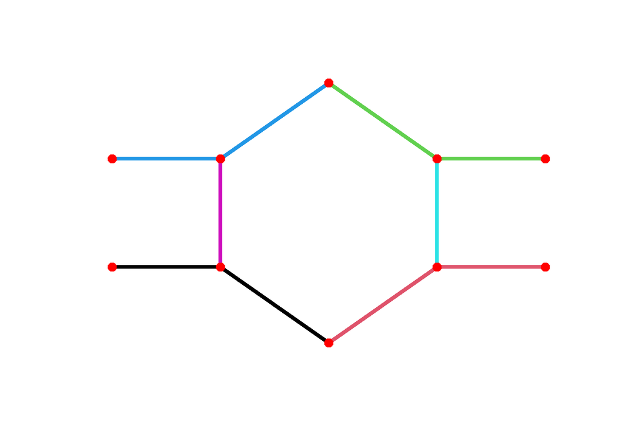

```r
library(sfnetworks)
library(sf)
library(tidygraph)

p1 <- st_point(c(0, 0))
p2 <- st_point(c(1, 0))
p3 <- st_point(c(2,-0.7))
p4 <- st_point(c(3,0))
p5 <- st_point(c(4,0))
p6 <- st_point(c(4,1))
p7 <- st_point(c(3,1))
p8 <- st_point(c(2,1.7))
p9 <- st_point(c(1,1))
p10 <- st_point(c(0,1))

l1 <- st_sfc(st_linestring(c(p1, p2, p3)))
l2 <- st_sfc(st_linestring(c(p3, p4, p5)))
l3 <- st_sfc(st_linestring(c(p6, p7, p8)))
l4 <- st_sfc(st_linestring(c(p8, p9, p10)))
l5 <- st_sfc(st_linestring(c(p4, p7)))
l6 <- st_sfc(st_linestring(c(p9, p2)))

lines <- c(l1, l2, l3, l4, l5, l6)

net <- as_sfnetwork(lines)

plot(st_geometry(net, "edges"), col = palette(rainbow(10)), lwd = 4)
plot(st_geometry(net, "nodes"), pch = 20, cex = 2, add = TRUE)
```

Treatment of the data starts with removing psudo nodes (with one parent and one child).

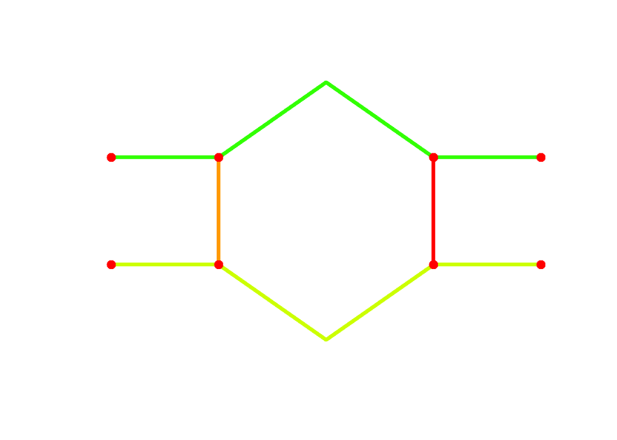

```r
smooth_net<-convert(net,to_spatial_smooth)

plot(st_geometry(smooth_net, "edges"), col = palette(rainbow(10)), lwd = 4)
plot(st_geometry(smooth_net, "nodes"), pch = 20, cex = 2, add = TRUE)
```

The smoothed network now has 8 nodes and 4 edges. Note that the nodes are re-numbered as 1 ~ 8.

For this example, we also need to split some edges at joints with another edge. This is usually not necessary for OpenStreetMap data but may be necessary for some other data sources.

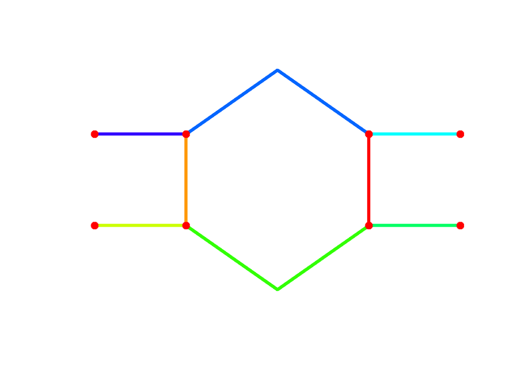

```r
clean_net <- convert(smooth_net, to_spatial_subdivision)

plot(st_geometry(clean_net, "edges"), col = palette(rainbow(10)), lwd = 4)
plot(st_geometry(clean_net, "nodes"), pch = 20, cex = 2, add = TRUE)
```

More instruction about data cleaning can be found [here](https://luukvdmeer.github.io/sfnetworks/articles/sfn02_preprocess_clean.html).

Now we will identify unique simple routes for the roadway alignment analysis. The goal is to cover the entire network but minimize duplicates. The method proposed here is to first identify all starting points (no edge leads to it) and ending points (no edge starts from it) in the network. Then find all the simple paths (no looping) from all starting points to all ending points.

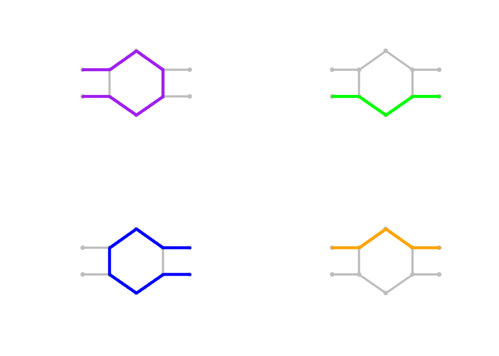

```r
sfc_edges <- st_as_sf(clean_net, "edges")
start_pts <- setdiff(sfc_edges$from, sfc_edges$to)
end_pts <- setdiff(sfc_edges$to, sfc_edges$from)


n_paths = st_network_paths(clean_net, from = start_pts[1], to=end_pts,type = "all_simple" )
for (i in start_pts[-1]) {
  pathi <- st_network_paths(clean_net, from = i, to = end_pts, type = "all_simple")
  n_paths <- rbind(n_paths, pathi)
}

find_epath <- function(array) {
  ep <- st_network_paths(clean_net, from = head(array, 1), to = tail(array, 1)) %>%
    pull(edge_paths) %>%
    unlist()
  return(sfc_edges[ep, ] %>% st_union() %>% st_sf())
}

ls <- lapply(n_paths %>% pull(node_paths), find_epath)

e_paths <- do.call(rbind, ls)

par(mfrow = c(2, 2))
plot(net, col = "gray", lwd = 3)
plot(e_paths[1, ], lwd = 4, col = "purple", add = TRUE)
plot(net, col = "gray", lwd = 3)
plot(e_paths[2, ], lwd = 4, col = "green", add = TRUE)
plot(net, col = "gray", lwd = 3)
plot(e_paths[3, ], lwd = 4, col = "blue", add = TRUE)
plot(net, col = "gray", lwd = 3)
plot(e_paths[4, ], lwd = 4, col = "orange", add = TRUE)
```

Four unique simple routes have been identified. There are duplicates between some routes. This means that a short curve or tangent segment detected from one route may be part of a longer curve or tangent segment detected from another route. This kind of overlaps can be addressed later by the geometry manipulating functions in the ‘sf’ package.

Wrap the above code in a function

```r
get_routes <- function(sfc){
  library(sfnetworks)
  library(tidygraph)

  net <- as_sfnetwork(sfc$geometry)
  smooth_net<-convert(net,to_spatial_smooth)
  clean_net <- convert(smooth_net, to_spatial_subdivision)

  sfc_edges <- st_as_sf(clean_net, "edges")
  start_pts <- setdiff(sfc_edges$from, sfc_edges$to)
  end_pts <- setdiff(sfc_edges$to, sfc_edges$from)


  n_paths = st_network_paths(clean_net, from = start_pts[1], to=end_pts,type = "all_simple" )
  for (i in start_pts[-1]) {
    pathi <- st_network_paths(clean_net, from = i, to = end_pts, type = "all_simple")
    n_paths <- rbind(n_paths, pathi)
  }

  find_epath <- function(array) {
    ep <- st_network_paths(clean_net, from = head(array, 1), to = tail(array, 1)) %>%
      pull(edge_paths) %>%
      unlist()
    return(sfc_edges[ep, ] %>% st_union() %>% st_sf())
  }

  ls <- lapply(n_paths %>% pull(node_paths), find_epath)

  e_paths <- do.call(rbind, ls)
  return(e_paths)
}
```

Now let’s test it with a real-world example: the interstate highway in Atlanta, Georgia.

```r
library(osmdata)
library(leaflet)
library(sf)

bbox = getbb("Atlanta, Georgia")

opq <- bbox %>%
  opq() %>%
  add_osm_feature(key = "highway", value = c("motorway")) %>%
  osmdata_sf()

roads <- opq$osm_lines %>% filter(ref %in% c("I 285", "I 85", "I 75", "I 75;I 85", "I 20"))

leaflet() %>%
  addProviderTiles(providers$CartoDB.Positron) %>%
  addPolylines(data = roads, color = palette(rainbow(20)), weight = 3) %>%
  addScaleBar(position = "bottomleft")
```

[interactive chart not shown]

The raw road shape data is an sfc object with 643 segments. In the above figure, adjacent segments are plotted with alternating colors.

Now apply the get_routes() function. The function returned 18 unique simple routes.

```r
routes <- get_routes(roads)

leaflet() %>%
  addProviderTiles(providers$CartoDB.Positron) %>%
  addPolylines(data = routes, color = palette(rainbow(nrow(routes))), weight = 3) %>%
  addScaleBar(position='bottomleft')
```

[interactive chart not shown]